# Predict Bike Sharing Demand with AutoGluon Template

## Project: Predict Bike Sharing Demand with AutoGluon

This notebook is a template with each step that you need to complete for the project.

Please fill in your code where there are explicit `?` markers in the notebook. You are welcome to add more cells and code as you see fit.

Once you have completed all the code implementations, please export your notebook as a HTML file so the reviews can view your code. Make sure you have all outputs correctly outputted.

`File-> Export Notebook As... -> Export Notebook as HTML`

There is a writeup to complete as well after all code implememtation is done. Please answer all questions and attach the necessary tables and charts. You can complete the writeup in either markdown or PDF.

Completing the code template and writeup template will cover all of the rubric points for this project.

The rubric contains "Stand Out Suggestions" for enhancing the project beyond the minimum requirements. The stand out suggestions are optional. If you decide to pursue the "stand out suggestions", you can include the code in this notebook and also discuss the results in the writeup file.

## Step 1: Create an account with Kaggle

### Create Kaggle Account and download API key

Below is example of steps to get the API username and key. Each student will have their own username and key.

1. Open account settings.

2. Scroll down to API and click Create New API Token.

3. Open up `kaggle.json` and use the username and key.


## Step 2: Download the Kaggle dataset using the kaggle python library

### Open up Sagemaker Studio and use starter template

1. Notebook should be using a `ml.t3.medium` instance (2 vCPU + 4 GiB)
2. Notebook should be using kernal: `Python 3 (MXNet 1.8 Python 3.7 CPU Optimized)`

### Install packages

```python
#!pip install -U pip
#!pip install -U setuptools wheel
#!pip install -U "mxnet<2.0.0" bokeh==2.0.1
#!pip install autogluon --no-cache-dir
# Without --no-cache-dir, smaller aws instances may have trouble installing
```

### Setup Kaggle API Key

```python
!mkdir -p ~/.kaggle
!touch ~/.kaggle/kaggle.json
!chmod 600 ~/.kaggle/kaggle.json
```

```python
# Fill in your user name and key from creating the kaggle account and API token file
import json
import os
kaggle_username = "moanlobago"
kaggle_key = "472e8de22c9480d5ae3d760141b952a9"

# Save API token the kaggle.json file
#with open("/root/.kaggle/kaggle.json", "w") as f:
#with open("~/.kaggle/kaggle.json", "w") as f:
    #f.write(json.dumps({"username": kaggle_username, "key": kaggle_key}))

# Get the full path of the user's home directory
home_dir = os.path.expanduser("~")

# Construct the full path to the kaggle.json file
kaggle_json_path = os.path.join(home_dir, ".kaggle", "kaggle.json")

# Write to the kaggle.json file
with open(kaggle_json_path, "w") as f:
    f.write(json.dumps({"username": kaggle_username, "key": kaggle_key}))
```

### Download and explore dataset

### Go to the bike sharing demand competition and agree to the terms

```python
#!pip install kaggle
```

```python
# Download the dataset, it will be in a .zip file so you'll need to unzip it as well.
!kaggle competitions download -c bike-sharing-demand
# If you already downloaded it you can use the -o command to overwrite the file
!unzip -o bike-sharing-demand.zip
```

```
Downloading bike-sharing-demand.zip to /home/moan/Udacity_ml/Project_1/Predict_Bike_Sharing_Demand/project
Archive:  bike-sharing-demand.zip
  inflating: sampleSubmission.csv
  inflating: test.csv
  inflating: train.csv
```

```python
import pandas as pd
from autogluon.tabular import TabularPredictor
```

```python
# Create the train dataset in pandas by reading the csv
# Set the parsing of the datetime column so you can use some of the `dt` features in pandas later
train = pd.read_csv("train.csv")
train.head()
```

|  | datetime | season | holiday | workingday | weather | temp | atemp | humidity | windspeed | casual | registered | count |
| --- | --- | --- | --- | --- | --- | --- | --- | --- | --- | --- | --- | --- |
| 0 | 2011-01-01 00:00:00 | 1 | 0 | 0 | 1 | 9.84 | 14.395 | 81 | 0.0 | 3 | 13 | 16 |
| 1 | 2011-01-01 01:00:00 | 1 | 0 | 0 | 1 | 9.02 | 13.635 | 80 | 0.0 | 8 | 32 | 40 |
| 2 | 2011-01-01 02:00:00 | 1 | 0 | 0 | 1 | 9.02 | 13.635 | 80 | 0.0 | 5 | 27 | 32 |
| 3 | 2011-01-01 03:00:00 | 1 | 0 | 0 | 1 | 9.84 | 14.395 | 75 | 0.0 | 3 | 10 | 13 |
| 4 | 2011-01-01 04:00:00 | 1 | 0 | 0 | 1 | 9.84 | 14.395 | 75 | 0.0 | 0 | 1 | 1 |

```python
# Create the test pandas dataframe in pandas by reading the csv, remember to parse the datetime!
test = pd.read_csv("test.csv")
test.head()
```

|  | datetime | season | holiday | workingday | weather | temp | atemp | humidity | windspeed |
| --- | --- | --- | --- | --- | --- | --- | --- | --- | --- |
| 0 | 2011-01-20 00:00:00 | 1 | 0 | 1 | 1 | 10.66 | 11.365 | 56 | 26.0027 |
| 1 | 2011-01-20 01:00:00 | 1 | 0 | 1 | 1 | 10.66 | 13.635 | 56 | 0.0000 |
| 2 | 2011-01-20 02:00:00 | 1 | 0 | 1 | 1 | 10.66 | 13.635 | 56 | 0.0000 |
| 3 | 2011-01-20 03:00:00 | 1 | 0 | 1 | 1 | 10.66 | 12.880 | 56 | 11.0014 |
| 4 | 2011-01-20 04:00:00 | 1 | 0 | 1 | 1 | 10.66 | 12.880 | 56 | 11.0014 |

```python
# Same thing as train and test dataset
submission = pd.read_csv("sampleSubmission.csv")
submission.head()
```

|  | datetime | count |
| --- | --- | --- |
| 0 | 2011-01-20 00:00:00 | 0 |
| 1 | 2011-01-20 01:00:00 | 0 |
| 2 | 2011-01-20 02:00:00 | 0 |
| 3 | 2011-01-20 03:00:00 | 0 |
| 4 | 2011-01-20 04:00:00 | 0 |

## Step 3: Train a model using AutoGluon’s Tabular Prediction

Requirements:

- We are prediting `count`, so it is the label we are setting.
- Ignore `casual` and `registered` columns as they are also not present in the test dataset.
- Use the `root_mean_squared_error` as the metric to use for evaluation.
- Set a time limit of 10 minutes (600 seconds).
- Use the preset `best_quality` to focus on creating the best model.

```python
ignore_columns = ['casual', 'registered']
```

```python
predictor = TabularPredictor(label = "count",
                             problem_type='regression',
                             eval_metric='root_mean_squared_error',
                             learner_kwargs={'ignored_columns': ignore_columns}).fit(train_data = train,
                                                                time_limit = 600,
                                                                presets = "best_quality")
```

```
No path specified. Models will be saved in: "AutogluonModels/ag-20240426_102514"
Presets specified: ['best_quality']
Setting dynamic_stacking from 'auto' to True. Reason: Enable dynamic_stacking when use_bag_holdout is disabled. (use_bag_holdout=False)
Stack configuration (auto_stack=True): num_stack_levels=1, num_bag_folds=8, num_bag_sets=1
Dynamic stacking is enabled (dynamic_stacking=True). AutoGluon will try to determine whether the input data is affected by stacked overfitting and enable or disable stacking as a consequence.
Detecting stacked overfitting by sub-fitting AutoGluon on the input data. That is, copies of AutoGluon will be sub-fit on subset(s) of the data. Then, the holdout validation data is used to detect stacked overfitting.
Sub-fit(s) time limit is: 600 seconds.
Starting holdout-based sub-fit for dynamic stacking. Context path is: AutogluonModels/ag-20240426_102514/ds_sub_fit/sub_fit_ho.
Running the sub-fit in a ray process to avoid memory leakage.
Spend 177 seconds for the sub-fit(s) during dynamic stacking.
Time left for full fit of AutoGluon: 423 seconds.
Starting full fit now with num_stack_levels 1.
Beginning AutoGluon training ... Time limit = 423s
AutoGluon will save models to "AutogluonModels/ag-20240426_102514"
=================== System Info ===================
AutoGluon Version:  1.1.0
Python Version:     3.11.5
Operating System:   Linux
Platform Machine:   x86_64
Platform Version:   #15~22.04.1-Ubuntu SMP PREEMPT_DYNAMIC Fri Jan 12 18:54:30 UTC 2
CPU Count:          4
Memory Avail:       2.37 GB / 7.62 GB (31.1%)
Disk Space Avail:   115.46 GB / 233.18 GB (49.5%)
===================================================
Train Data Rows:    10886
Train Data Columns: 11
Label Column:       count
Problem Type:       regression
Preprocessing data ...
Using Feature Generators to preprocess the data ...
Dropping user-specified ignored columns: ['casual', 'registered']
Fitting AutoMLPipelineFeatureGenerator...
	Available Memory:                    2443.03 MB
	Train Data (Original)  Memory Usage: 1.45 MB (0.1% of available memory)
	Inferring data type of each feature based on column values. Set feature_metadata_in to manually specify special dtypes of the features.
	Stage 1 Generators:
		Fitting AsTypeFeatureGenerator...
			Note: Converting 2 features to boolean dtype as they only contain 2 unique values.
	Stage 2 Generators:
		Fitting FillNaFeatureGenerator...
```

[output cut: 94 more lines]

```
	Fitting 8 child models (S1F1 - S1F8) | Fitting with ParallelLocalFoldFittingStrategy (4 workers, per: cpus=1, gpus=0, memory=0.53%)
	-55.7915	 = Validation score   (-root_mean_squared_error)
	42.98s	 = Training   runtime
	0.09s	 = Validation runtime
Fitting model: ExtraTreesMSE_BAG_L2 ... Training model for up to 6.48s of the 6.43s of remaining time.
	-53.72	 = Validation score   (-root_mean_squared_error)
	7.13s	 = Training   runtime
	0.6s	 = Validation runtime
Fitting model: WeightedEnsemble_L3 ... Training model for up to 360.0s of the -2.27s of remaining time.
	Ensemble Weights: {'RandomForestMSE_BAG_L2': 0.52, 'ExtraTreesMSE_BAG_L2': 0.32, 'LightGBM_BAG_L2': 0.16}
	-52.5869	 = Validation score   (-root_mean_squared_error)
	0.07s	 = Training   runtime
	0.0s	 = Validation runtime
AutoGluon training complete, total runtime = 425.38s ... Best model: "WeightedEnsemble_L3"
TabularPredictor saved. To load, use: predictor = TabularPredictor.load("AutogluonModels/ag-20240426_102514")
```

### Review AutoGluon's training run with ranking of models that did the best.

```python
predictor.fit_summary()
```

[output not shown]

[output not shown]

[output cut: 126 more lines]

```
     stack_level  can_infer  fit_order
 0             3       True         14
 1             2       True         12
 2             2       True         11
 3             2       True         13
 4             2       True         10
 5             1       True          2
 6             2       True          9
 7             1       True          1
 8             1       True          5
 9             1       True          7
 10            1       True          6
 11            1       True          4
 12            1       True          3
 13            1       True          8  }
```

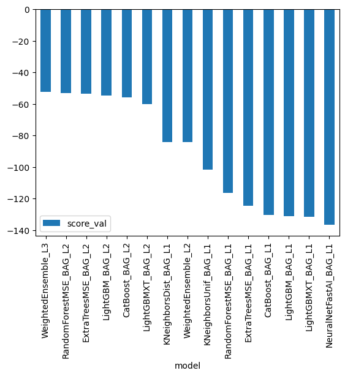

```python
predictor.leaderboard(silent = True).plot(kind="bar", x = "model", y="score_val");
```

### Create predictions from test dataset

```python
predictions = predictor.predict(test)
predictions.head()
```

[output not shown]

[output cut: 377 more lines]

[output not shown]

```
0    26.019588
1    44.723572
2    50.539268
3    54.205399
4    56.115959
Name: count, dtype: float32
```

#### NOTE: Kaggle will reject the submission if we don't set everything to be > 0.

```python
# Describe the `predictions` series to see if there are any negative values
predictions.describe()
```

```
count    6493.000000
mean      120.564201
std       114.351326
min         3.206649
25%        21.847420
50%        72.432640
75%       203.575592
max       437.510132
Name: count, dtype: float64
```

```python
train["count"].describe()
```

```
count    10886.000000
mean       191.574132
std        181.144454
min          1.000000
25%         42.000000
50%        145.000000
75%        284.000000
max        977.000000
Name: count, dtype: float64
```

```python
# How many negative values do we have?
predictions[predictions < 0]
```

```
Series([], Name: count, dtype: float32)
```

```python
# Set them to zero
predictions[predictions < 0] = 0
```

### Set predictions to submission dataframe, save, and submit

```python
submission["count"] = predictions
submission.to_csv("submission.csv", index=False)
```

```python
!kaggle competitions submit -c bike-sharing-demand -f submission.csv -m "first raw submission"
```

```
Successfully submitted to Bike Sharing Demand
```

#### View submission via the command line or in the web browser under the competition's page - `My Submissions`

```python
!kaggle competitions submissions -c bike-sharing-demand | tail -n +1 | head -n 6
```

```
fileName                     date                 description                        status    publicScore  privateScore
---------------------------  -------------------  ---------------------------------  --------  -----------  ------------
submission.csv               2024-04-26 10:37:26  first raw submission               complete  1.85863      1.85863
submission_new_hpo.csv       2024-04-26 08:50:21  new features with hyperparameters  complete  0.46783      0.46783
submission_new_hpo.csv       2024-04-25 21:51:02  new features with hyperparameters  complete  0.73601      0.73601
submission_new_features.csv  2024-04-25 21:13:01  new features                       complete  0.73601      0.73601
```

#### Initial score of `1.85863`

## Step 4: Exploratory Data Analysis and Creating an additional feature

- Any additional feature will do, but a great suggestion would be to separate out the datetime into hour, day, or month parts.

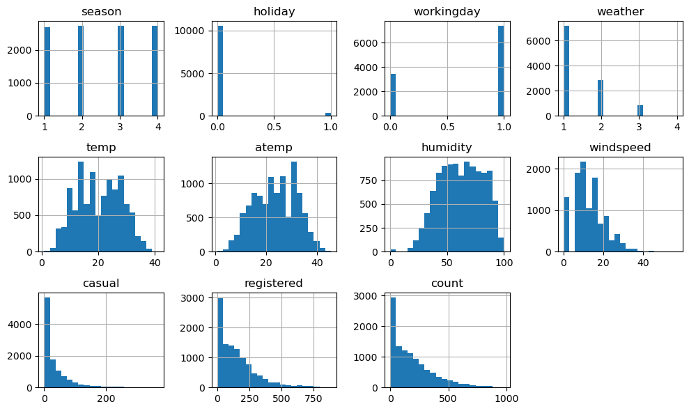

```python
import matplotlib.pyplot as plt
# Create a histogram of all features to show the distribution of each one relative to the data. This is part of the exploritory data analysis

train.hist(figsize = (10, 6), layout = (3, -1), bins = 20)
plt.tight_layout()
plt.show()
```

*We will be ignoring `casual`, `registered`*

```python
train[["season", "weather"]].value_counts()
```

```
season  weather
3       1          1930
2       1          1801
1       1          1759
4       1          1702
        2           807
1       2           715
2       2           708
3       2           604
4       3           225
2       3           224
1       3           211
3       3           199
1       4             1
Name: count, dtype: int64
```

```python
#Season-weather map

# Define a lambda function to map season and weather values to the new column
#mapping_function = lambda row: row['season'] if (row['season'] == 1 and row['weather'] == 1) else row['season']

# Apply the lambda function to create the new column
#train['season_Weath'] = train.apply(mapping_function, axis=1)
#test['season_Weath'] = test.apply(mapping_function, axis=1)
```

```python
# create a new feature

train["datetime"] = pd.to_datetime(train["datetime"])
test["datetime"] = pd.to_datetime(test["datetime"])

train["year"] = train["datetime"].dt.year
train["month"] = train["datetime"].dt.month
train["day"] = train["datetime"].dt.day
train["dayofweek"] = train["datetime"].dt.dayofweek
train["hour"] = train["datetime"].dt.hour

test["year"] = test["datetime"].dt.year
test["month"] = test["datetime"].dt.month
test["day"] = test["datetime"].dt.day
test["dayofweek"] = test["datetime"].dt.dayofweek
test["hour"] = test["datetime"].dt.hour
```

## Make category types for these so models know they are not just numbers

- AutoGluon originally sees these as ints, but in reality they are int representations of a category.
- Setting the dtype to category will classify these as categories in AutoGluon.

```python
train["season"] = train["season"].astype("category")
train["weather"] = train["weather"].astype("category")
test["season"] = test["season"].astype("category")
test["weather"] = test["weather"].astype("category")
```

```python
# View are new feature
train.head()
```

|  | datetime | season | holiday | workingday | weather | temp | atemp | humidity | windspeed | casual | registered | count | year | month | day | dayofweek | hour |
| --- | --- | --- | --- | --- | --- | --- | --- | --- | --- | --- | --- | --- | --- | --- | --- | --- | --- |
| 0 | 2011-01-01 00:00:00 | 1 | 0 | 0 | 1 | 9.84 | 14.395 | 81 | 0.0 | 3 | 13 | 16 | 2011 | 1 | 1 | 5 | 0 |
| 1 | 2011-01-01 01:00:00 | 1 | 0 | 0 | 1 | 9.02 | 13.635 | 80 | 0.0 | 8 | 32 | 40 | 2011 | 1 | 1 | 5 | 1 |
| 2 | 2011-01-01 02:00:00 | 1 | 0 | 0 | 1 | 9.02 | 13.635 | 80 | 0.0 | 5 | 27 | 32 | 2011 | 1 | 1 | 5 | 2 |
| 3 | 2011-01-01 03:00:00 | 1 | 0 | 0 | 1 | 9.84 | 14.395 | 75 | 0.0 | 3 | 10 | 13 | 2011 | 1 | 1 | 5 | 3 |
| 4 | 2011-01-01 04:00:00 | 1 | 0 | 0 | 1 | 9.84 | 14.395 | 75 | 0.0 | 0 | 1 | 1 | 2011 | 1 | 1 | 5 | 4 |

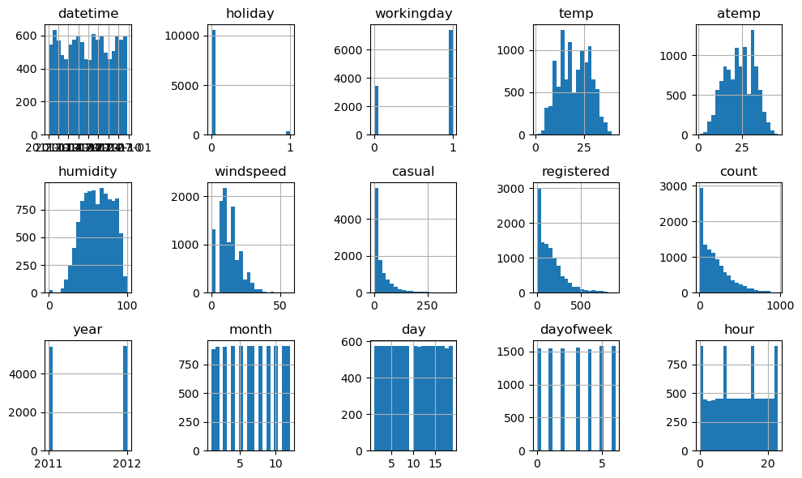

```python
# View histogram of all features again now with the hour feature
train.hist(figsize = (10, 6), layout = (3, -1), bins = 20)
plt.tight_layout()
plt.show()
```

## Step 5: Rerun the model with the same settings as before, just with more features

```python
predictor_new_features = TabularPredictor(label = "count",
                             problem_type='regression',
                             eval_metric='root_mean_squared_error',
                             learner_kwargs={'ignored_columns': ignore_columns}).fit(train_data = train,
                                                                time_limit = 600,
                                                                presets = "best_quality")
```

```
No path specified. Models will be saved in: "AutogluonModels/ag-20240426_103840"
Presets specified: ['best_quality']
Setting dynamic_stacking from 'auto' to True. Reason: Enable dynamic_stacking when use_bag_holdout is disabled. (use_bag_holdout=False)
Stack configuration (auto_stack=True): num_stack_levels=1, num_bag_folds=8, num_bag_sets=1
Dynamic stacking is enabled (dynamic_stacking=True). AutoGluon will try to determine whether the input data is affected by stacked overfitting and enable or disable stacking as a consequence.
Detecting stacked overfitting by sub-fitting AutoGluon on the input data. That is, copies of AutoGluon will be sub-fit on subset(s) of the data. Then, the holdout validation data is used to detect stacked overfitting.
Sub-fit(s) time limit is: 600 seconds.
Starting holdout-based sub-fit for dynamic stacking. Context path is: AutogluonModels/ag-20240426_103840/ds_sub_fit/sub_fit_ho.
Running the sub-fit in a ray process to avoid memory leakage.
Spend 180 seconds for the sub-fit(s) during dynamic stacking.
Time left for full fit of AutoGluon: 420 seconds.
Starting full fit now with num_stack_levels 1.
Beginning AutoGluon training ... Time limit = 420s
AutoGluon will save models to "AutogluonModels/ag-20240426_103840"
=================== System Info ===================
AutoGluon Version:  1.1.0
Python Version:     3.11.5
Operating System:   Linux
Platform Machine:   x86_64
Platform Version:   #15~22.04.1-Ubuntu SMP PREEMPT_DYNAMIC Fri Jan 12 18:54:30 UTC 2
CPU Count:          4
Memory Avail:       2.45 GB / 7.62 GB (32.1%)
Disk Space Avail:   114.19 GB / 233.18 GB (49.0%)
===================================================
Train Data Rows:    10886
Train Data Columns: 16
Label Column:       count
Problem Type:       regression
Preprocessing data ...
Using Feature Generators to preprocess the data ...
Dropping user-specified ignored columns: ['casual', 'registered']
Fitting AutoMLPipelineFeatureGenerator...
	Available Memory:                    2505.55 MB
	Train Data (Original)  Memory Usage: 0.81 MB (0.0% of available memory)
	Inferring data type of each feature based on column values. Set feature_metadata_in to manually specify special dtypes of the features.
	Stage 1 Generators:
		Fitting AsTypeFeatureGenerator...
			Note: Converting 3 features to boolean dtype as they only contain 2 unique values.
	Stage 2 Generators:
		Fitting FillNaFeatureGenerator...
```

[output cut: 94 more lines]

```
	-31.354	 = Validation score   (-root_mean_squared_error)
	28.29s	 = Training   runtime
	0.67s	 = Validation runtime
Fitting model: CatBoost_BAG_L2 ... Training model for up to 50.92s of the 50.83s of remaining time.
	Fitting 8 child models (S1F1 - S1F8) | Fitting with ParallelLocalFoldFittingStrategy (4 workers, per: cpus=1, gpus=0, memory=0.58%)
	-30.2282	 = Validation score   (-root_mean_squared_error)
	45.54s	 = Training   runtime
	0.19s	 = Validation runtime
Fitting model: WeightedEnsemble_L3 ... Training model for up to 360.0s of the 1.12s of remaining time.
	Ensemble Weights: {'CatBoost_BAG_L2': 0.5, 'LightGBM_BAG_L2': 0.375, 'LightGBMXT_BAG_L2': 0.062, 'RandomForestMSE_BAG_L2': 0.062}
	-29.9791	 = Validation score   (-root_mean_squared_error)
	0.08s	 = Training   runtime
	0.0s	 = Validation runtime
AutoGluon training complete, total runtime = 418.99s ... Best model: "WeightedEnsemble_L3"
TabularPredictor saved. To load, use: predictor = TabularPredictor.load("AutogluonModels/ag-20240426_103840")
```

```python
predictor_new_features.fit_summary()
```

```
*** Summary of fit() ***
Estimated performance of each model:
                     model   score_val              eval_metric  pred_time_val    fit_time  pred_time_val_marginal  fit_time_marginal  stack_level  can_infer  fit_order
0      WeightedEnsemble_L3  -29.979076  root_mean_squared_error      36.249454  381.957586                0.000677           0.075424            3       True         14
1          CatBoost_BAG_L2  -30.228154  root_mean_squared_error      33.425393  319.974539                0.189206          45.541636            2       True         13
2          LightGBM_BAG_L2  -30.396724  root_mean_squared_error      33.738554  289.803322                0.502366          15.370420            2       True         11
3        LightGBMXT_BAG_L2  -31.010791  root_mean_squared_error      34.887898  292.675663                1.651711          18.242761            2       True         10
4   RandomForestMSE_BAG_L2  -31.353952  root_mean_squared_error      33.905494  302.727345                0.669307          28.294443            2       True         12
5      WeightedEnsemble_L2  -32.184554  root_mean_squared_error      31.996769  237.755569                0.001131           0.083621            2       True          9
6          LightGBM_BAG_L1  -33.917339  root_mean_squared_error       7.848500   30.430859                7.848500          30.430859            1       True          4
7          CatBoost_BAG_L1  -33.998650  root_mean_squared_error       0.671521  138.065945                0.671521         138.065945            1       True          6
8        LightGBMXT_BAG_L1  -34.411141  root_mean_squared_error      22.694160   58.044558               22.694160          58.044558            1       True          3
9     ExtraTreesMSE_BAG_L1  -38.386573  root_mean_squared_error       0.565391    5.287241                0.565391           5.287241            1       True          7
10  RandomForestMSE_BAG_L1  -38.446872  root_mean_squared_error       0.733784   11.110240                0.733784          11.110240            1       True          5
11   KNeighborsDist_BAG_L1  -84.175461  root_mean_squared_error       0.047673    0.020346                0.047673           0.020346            1       True          2
12  NeuralNetFastAI_BAG_L1  -88.178018  root_mean_squared_error       0.626487   31.450989                0.626487          31.450989            1       True          8
13   KNeighborsUnif_BAG_L1 -101.644380  root_mean_squared_error       0.048671    0.022723                0.048671           0.022723            1       True          1
Number of models trained: 14
Types of models trained:
{'StackerEnsembleModel_CatBoost', 'StackerEnsembleModel_RF', 'StackerEnsembleModel_XT', 'StackerEnsembleModel_LGB', 'StackerEnsembleModel_KNN', 'WeightedEnsembleModel', 'StackerEnsembleModel_NNFastAiTabular'}
Bagging used: True  (with 8 folds)
Multi-layer stack-ensembling used: True  (with 3 levels)
Feature Metadata (Processed):
(raw dtype, special dtypes):
('category', [])             : 2 | ['season', 'weather']
('float', [])                : 3 | ['temp', 'atemp', 'windspeed']
('int', [])                  : 5 | ['humidity', 'month', 'day', 'dayofweek', 'hour']
('int', ['bool'])            : 3 | ['holiday', 'workingday', 'year']
('int', ['datetime_as_int']) : 2 | ['datetime', 'datetime.year']
*** End of fit() summary ***
```

```
{'model_types': {'KNeighborsUnif_BAG_L1': 'StackerEnsembleModel_KNN',
  'KNeighborsDist_BAG_L1': 'StackerEnsembleModel_KNN',
  'LightGBMXT_BAG_L1': 'StackerEnsembleModel_LGB',
  'LightGBM_BAG_L1': 'StackerEnsembleModel_LGB',
  'RandomForestMSE_BAG_L1': 'StackerEnsembleModel_RF',
  'CatBoost_BAG_L1': 'StackerEnsembleModel_CatBoost',
  'ExtraTreesMSE_BAG_L1': 'StackerEnsembleModel_XT',
  'NeuralNetFastAI_BAG_L1': 'StackerEnsembleModel_NNFastAiTabular',
  'WeightedEnsemble_L2': 'WeightedEnsembleModel',
  'LightGBMXT_BAG_L2': 'StackerEnsembleModel_LGB',
  'LightGBM_BAG_L2': 'StackerEnsembleModel_LGB',
  'RandomForestMSE_BAG_L2': 'StackerEnsembleModel_RF',
  'CatBoost_BAG_L2': 'StackerEnsembleModel_CatBoost',
  'WeightedEnsemble_L3': 'WeightedEnsembleModel'},
 'model_performance': {'KNeighborsUnif_BAG_L1': -101.64437969927306,
  'KNeighborsDist_BAG_L1': -84.17546135232182,
  'LightGBMXT_BAG_L1': -34.41114092915738,
  'LightGBM_BAG_L1': -33.91733862651761,
  'RandomForestMSE_BAG_L1': -38.44687214943684,
  'CatBoost_BAG_L1': -33.99864959331977,
  'ExtraTreesMSE_BAG_L1': -38.38657284139279,
  'NeuralNetFastAI_BAG_L1': -88.17801833643294,
  'WeightedEnsemble_L2': -32.18455410428449,
  'LightGBMXT_BAG_L2': -31.010790562327543,
  'LightGBM_BAG_L2': -30.396723601364656,
  'RandomForestMSE_BAG_L2': -31.35395189902737,
  'CatBoost_BAG_L2': -30.228154071679587,
  'WeightedEnsemble_L3': -29.9790755948709},
 'model_best': 'WeightedEnsemble_L3',
 'model_paths': {'KNeighborsUnif_BAG_L1': ['KNeighborsUnif_BAG_L1'],
  'KNeighborsDist_BAG_L1': ['KNeighborsDist_BAG_L1'],
  'LightGBMXT_BAG_L1': ['LightGBMXT_BAG_L1'],
  'LightGBM_BAG_L1': ['LightGBM_BAG_L1'],
  'RandomForestMSE_BAG_L1': ['RandomForestMSE_BAG_L1'],
  'CatBoost_BAG_L1': ['CatBoost_BAG_L1'],
  'ExtraTreesMSE_BAG_L1': ['ExtraTreesMSE_BAG_L1'],
  'NeuralNetFastAI_BAG_L1': ['NeuralNetFastAI_BAG_L1'],
  'WeightedEnsemble_L2': ['WeightedEnsemble_L2'],
  'LightGBMXT_BAG_L2': ['LightGBMXT_BAG_L2'],
  'LightGBM_BAG_L2': ['LightGBM_BAG_L2'],
```

[output cut: 126 more lines]

```
     stack_level  can_infer  fit_order
 0             3       True         14
 1             2       True         13
 2             2       True         11
 3             2       True         10
 4             2       True         12
 5             2       True          9
 6             1       True          4
 7             1       True          6
 8             1       True          3
 9             1       True          7
 10            1       True          5
 11            1       True          2
 12            1       True          8
 13            1       True          1  }
```

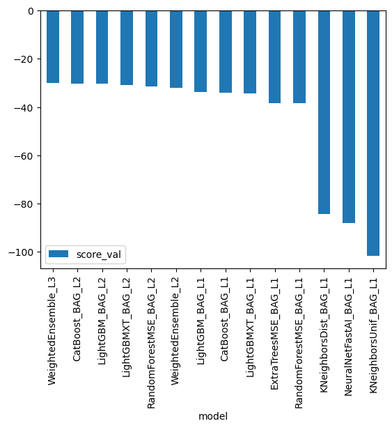

```python
predictor_new_features.leaderboard(silent = True).plot(kind="bar", x = "model", y="score_val");
```

```python
# Remember to set all negative values to zero
predictions = predictor_new_features.predict(test)
```

[output not shown]

[output cut: 377 more lines]

[output not shown]

```python
predictions[predictions < 0].sum()
```

```
0.0
```

```python
predictions.describe()
```

```
count    6493.000000
mean      156.398071
std       133.753815
min         1.780762
25%        57.793346
50%       121.044403
75%       220.333633
max       835.845459
Name: count, dtype: float64
```

```python
# Same submitting predictions

submission_new_features = submission.copy()
submission_new_features["count"] = predictions
submission_new_features.to_csv("submission_new_features.csv", index=False)
```

```python
!kaggle competitions submit -c bike-sharing-demand -f submission_new_features.csv -m "new features"
```

```
Successfully submitted to Bike Sharing Demand
```

```python
!kaggle competitions submissions -c bike-sharing-demand | tail -n +1 | head -n 6
```

```
fileName                     date                 description                        status    publicScore  privateScore
---------------------------  -------------------  ---------------------------------  --------  -----------  ------------
submission_new_features.csv  2024-04-26 10:51:15  new features                       complete  0.72806      0.72806
submission.csv               2024-04-26 10:37:26  first raw submission               complete  1.85863      1.85863
submission_new_hpo.csv       2024-04-26 08:50:21  new features with hyperparameters  complete  0.46783      0.46783
submission_new_hpo.csv       2024-04-25 21:51:02  new features with hyperparameters  complete  0.73601      0.73601
```